# Regularized Regressions

## Dimensionality Reduction

Another way to approach this issue is by using so-called dimensionality techniques. One example is the principal component approach where you define new predictors that are orthogonal linear combinations of the raw data with the intention of maximizing variance in some of these new directions that you define.

```r
model.pcr <- train(MEDV ~ .,
                   data = train.preproc,
                   method = "pcr",
                   tuneLength = 13)
```

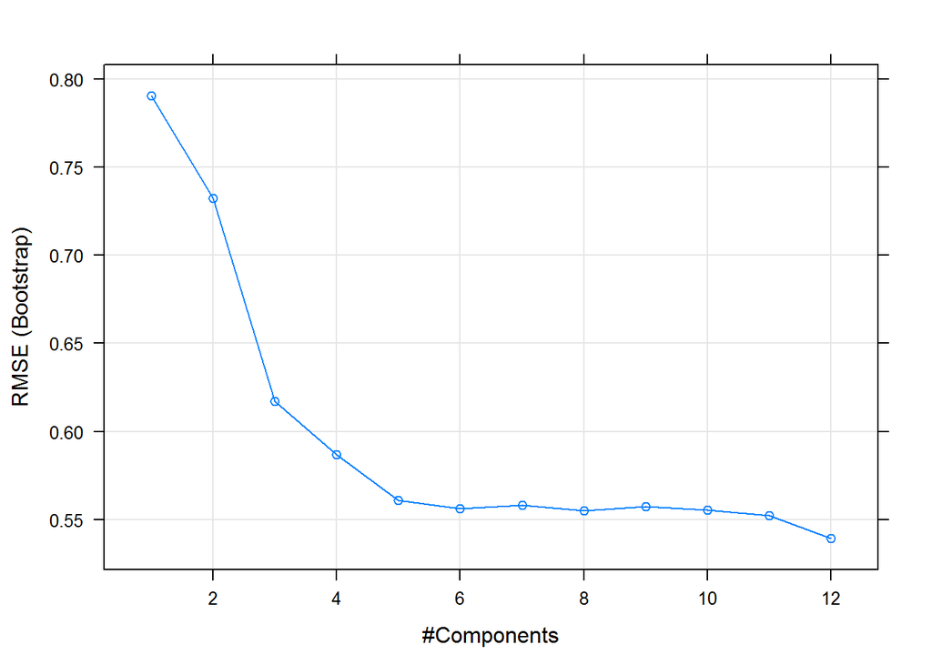

```r
plot(model.pcr)
```

Using this method, minimum RMSE is acheived by including 12 components, which means that dimensionality reduction doesn’t seem terribly effective, but the RMSE from including only 5 components is only marginally worse, so we can do almost as well even if we drop 8 of our 13 dimensions. The only model that appears to beat OLS is the lasso with fraction = .9.